# Orientation

## What’s an Open Lab?

Open labs are (mostly) unstructured workshops designed to help you learn R. Each week brief instruction will be provided, followed by time to practice, work together, ask questions and get help. Participants can join the lab any time during the session, and are welcome to work on unrelated projects.

The Open Labs model was established by our colleagues at Columbia with excellent results, and now we’re giving it a try. Our goal is to connect researchers and foster a community for R users on campus.

## Today

This introductory workshop aims to:

- Install R and R Studio if you haven’t already
- Briefly familiarize or re-familiarize you with some of the most important elements of R
  - Objects
  - Libraries
  - Working Directories

This workshop **does not** aim to give a comprehensive introduction to R. We assume most attendees have at least some R experience.

If you don’t have any R experience, don’t worry! The Open Labs can still provide support and a community to help you learn, **but** you’ll need to work outside the Open Labs to learn some of the basics. The Odum Institute will provide more in-depth introductory and intermediate R workshops this September. For more information, see http://odum.unc.edu/events/2017-09/.

## Objects and Using Functions

First off! Like other statistical and programming languages, R has a way to make comments. The `#` indicates part of the script that has been ‘commented out.’ Always, always, always leave yourself (and others!) easy-to-follow comments.

In R, we use ‘object-oriented programming’: this means that we are creating ‘objects’ that are stored for use with either pre-programmed functions or functions that we create ourselves. This means that you can store anything you do in R as an object with a name, then look at that object, run another command on it later, overwrite it, or delete it as you see fit.

```r
1 + 3 # evaluation (more R terminology)
```

```
## [1] 4
```

```r
a <- 3 # assignment
a # evaluation
```

```
## [1] 3
```

```r
y<-3 # spacing does not matter
y<- 3 # spacing does not matter
a
```

```
## [1] 3
```

### Using Functions

We can use R as a calculator for basic functions.

Side note- what’s a function? In R, that means anything you’re telling the computer to do. This goes in parentheses - below, `log()` means ‘take the natural log’.

```r
log(a)
```

```
## [1] 1.098612
```

```r
y<-log(a) #What is the difference between this and the above line?
```

In the above example, the object `a` serves as the **argument** to the function `log`.

What do you think will happen when you execute the following?

```r
a<-y + f^2
```

`Error: object 'f' not found`

If we want to know what other functions R has, or if we have a question about how R is working we can use the help operators:

`?log`

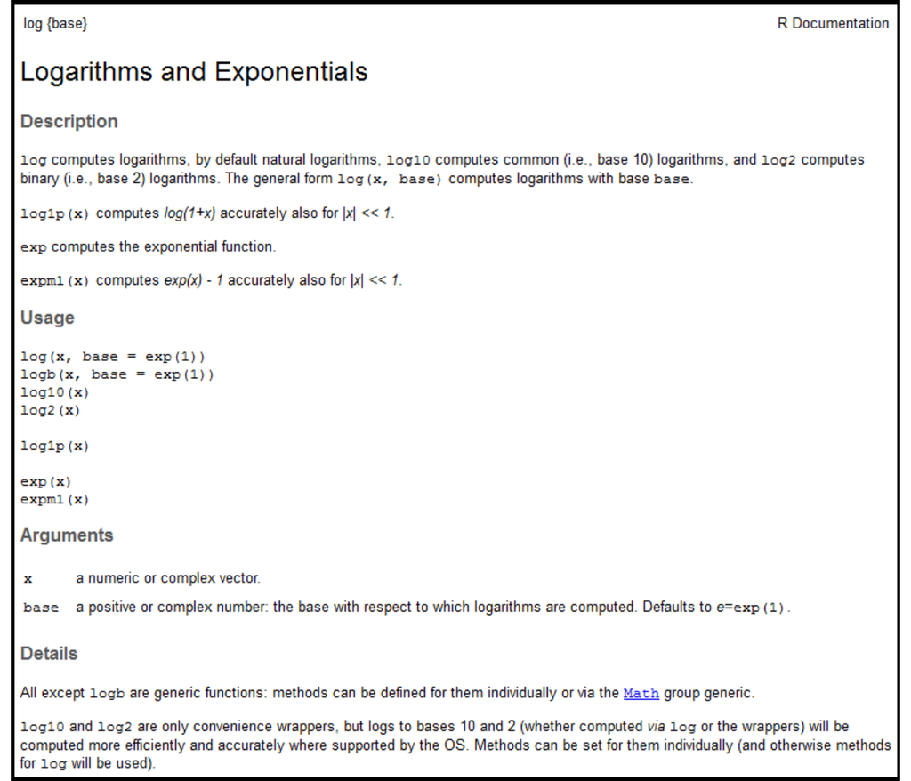

`??log`

[figure not shown]

**Exercise** Use `?` to determine what some other useful help functions, `help.start` and `apropos`, do.

### Working with Objects

Comparing objects:

```r
a == y # is a equivalent to y?
```

```
## [1] FALSE
```

```r
a != y # is a not equal to y?
```

```
## [1] TRUE
```

```r
a < y #is a less than y?
```

```
## [1] FALSE
```

Use the `ls()` function to list objects in the global environment – useful for keeping track of objects.

```r
ls()
```

```
## [1] "a"   "img" "y"
```

You can redefine an object at any time. You can also remove objects with `rm()`

```r
rm(a) # remove a single object
a<-4
ls() #did it work?
```

```
## [1] "a"   "img" "y"
```

For a completely clean start, remove **all** objects from your R session with:

```r
rm(list=ls(all=TRUE))
```

### Vectors

We will often find it useful to have a ‘list’ of objects (or a matrix or data frame, but we’ll cover that later). R calls these lists of objects “vectors”.

```r
my.vector <- c(1, 2, 3, 4, 5) #This function is called 'concatenate'
my.vector
```

```
## [1] 1 2 3 4 5
```

The `c` function combines all of its arguments to form a vector object. `c` also works with string (and many other) type objects.

```r
my.vector.2 <- c("one","three","five")
my.vector.2
```

```
## [1] "one"   "three" "five"
```

You can check the type of a vector or other object with `class`.

```r
class(my.vector)
```

```
## [1] "numeric"
```

```r
class(my.vector.2)
```

```
## [1] "character"
```

### Data Frames

Data frames are often the fundamental structure for datasets in R. A data frame groups several vectors, potentially of different types, and stores names for each vector.

Here, we’ll manually enter the monthly unemployment and presidential approval data from Jan-July 2015.

```r
unemployment <- c(7.9, 7.7, 7.6, 7.5, 7.6, 7.6, 7.4)
approval <- c(52, 51, 48, 49, 49, 47, 46)
```

We can then use `data.frame` to combine these vectors into the data frame structure.

```r
my_data <- data.frame(unemployment,approval)
```

It is conventional in R to use columns to store variables, where each row represents a different case or observation. This is similar to other common statistical software, but not necessarily natural to other software or fields.

We can see a quick summary of the data frame using the `str` command.

```r
str(my_data)
```

```
## 'data.frame':    7 obs. of  2 variables:
##  $ unemployment: num  7.9 7.7 7.6 7.5 7.6 7.6 7.4
##  $ approval    : num  52 51 48 49 49 47 46
```

### Indexing

Now that we have multiple values assigned to one object, we sometimes need to retrieve specific values.

Recall `my.vector`

```r
my.vector <- c(1, 2, 3, 4, 5)
my.vector
```

```
## [1] 1 2 3 4 5
```

We use `[]` after an object name to specify a particular entry.

**NOTE:** R starts counting at 1, not 0 as in many other languages. So `object[1]` refers to the first entry in the object.

```r
my.vector[2]
```

```
## [1] 2
```

Multiple indexes can also be passed using a vector.

```r
my.vector[c(1,2,3)]
```

```
## [1] 1 2 3
```

For a data frame (or matrix), we need to supply **two** indexes for rows and columns respectively. Indexes are always provided in **row, column** order. Recall `my_data`.

```r
print(my_data)
```

```
##   unemployment approval
## 1          7.9       52
## 2          7.7       51
## 3          7.6       48
## 4          7.5       49
## 5          7.6       49
## 6          7.6       47
## 7          7.4       46
```

To retrieve the second row of the first column:

```r
my_data[2,1]
```

```
## [1] 7.7
```

Alternatively, we can use the data frame’s vector names to retrieve data. The first column’s second row can also be retrieved as:

```r
my_data$unemployment[2]
```

```
## [1] 7.7
```

## Libraries

In addition to the basic R ‘language’, there are packages that can be downloaded for use- we have to install them and then these can be called with the command library().

The first time we install a package, we refer to it in quotes:

```r
install.packages("foreign")
```

We only need to **install** a package once. Thereafter, we have to tell R to load it **each time** we need it in a new session or script.

```r
library(foreign)
```

**Exercise**

Take a few minutes to search for available R packages (if you’re stuck, try here: https://cran.r-project.org/web/packages/available_packages_by_name.html) install and call one that could be relevant for your work.

## Working Directories

(Preview for next week)

In practice, you’ll often need to bring external data into R instead of defining all of your objects manually. Next week, we’ll discuss reading files into R. Before using R to read or write files, we need to tell R which folder to work in. There are two main ways to do this.

1. You can always provide the complete, or **absolute** file path to the file you’re using.
2. You can set a working directory and specify files by their path **relative** to the working directory.

You can check your current working directory with `getwd`. R always has a working directory set.

```r
getwd()
```

```
## [1] "C:/Users/mtjansen/Desktop/Workshops/2017_Fall"
```

You can check what files are in a directory with `list.files`. If no argument is provided, the working directory is used.

If we want R to interact with Important_Data.txt below, we need to use one of these approaches.

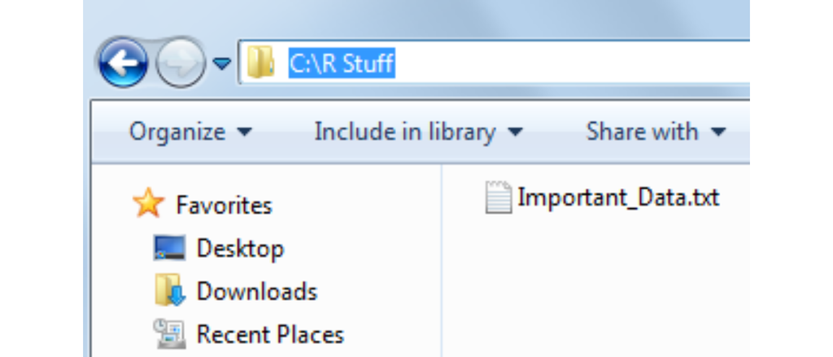

#### Note: File Paths in Windows

By default, Windows operating systems use the backslash, \, to separate folders in file paths. R follows the Unix system (also used by Linux and Mac systems) and uses the standard slash, /. Windows users should either replace \ with /, or replace \ with \\.

1. Absolute Path

```r
list.files("C:/R Stuff")
```

```
## [1] "Important_Data.txt"
```

2. Working Directory and Relative Path

We can **change** the current working directory with `setwd`.

```r
setwd("C:/R Stuff")
list.files()
```

```
## [1] "Important_Data.txt"
```

## Extras

### Mixed Types and Coercion

Vectors can only have one type - R will automatically coerce in the following order: Logical => Numeric => Character.

```r
x <- c(TRUE,1,3)
print(x)
```

```
## [1] 1 1 3
```

What class does this look like?

```r
class(x)
```

```
## [1] "numeric"
```

Another example

```r
y <- c(TRUE,1,"Cat")
print(y)
```

```
## [1] "TRUE" "1"    "Cat"
```

```r
class(y)
```

```
## [1] "character"
```

### `which` and Indexing

The `which` function is used to find the index for objects fulfilling a certain condition. In this example, we’ll use `which` to find observations greater than a particular value.

First, we generate 100 samples from a Normal(0,1) distribution.

**Note** Running `set.seed` ensures that you’ll get the same result shown here. Try defining testvec again and see what results you get.

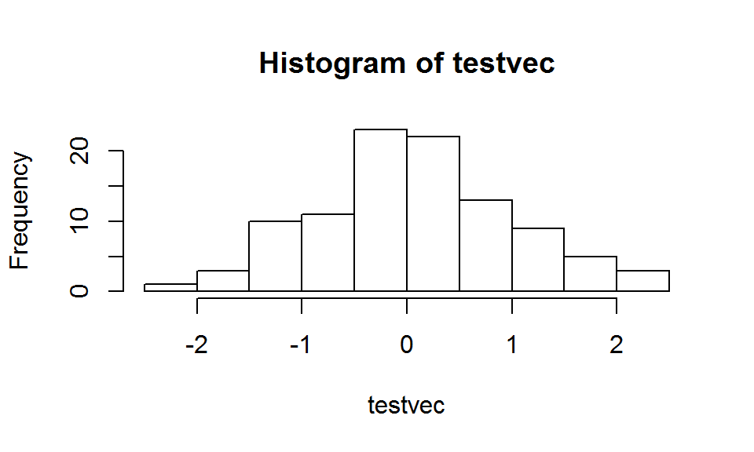

```r
set.seed(123)
testvec <- rnorm(100,0,1)
hist(testvec) #this produces a histogram of the values in testvec
```

We can use `which` to identify which of the 100 values are greater than 1.645.

```r
which(testvec>1.645)
```

```
## [1]  6 16 44 70 97
```

We can also use `which` with indexing to determine the actual values the vector.

```r
testvec[which(testvec>1.645)]
```

```
## [1] 1.715065 1.786913 2.168956 2.050085 2.187333
```

### Factors

R uses factors to help deal with categorical data. Factors use integers to store data behind the scenes, while displaying assigned text labels. In many cases, character vectors and factors are treated similarly, but factors can make certain tasks easier.

```r
students <- sample(c(1,2,3,4),50, replace=TRUE)
print(students)
```

```
##  [1] 1 4 3 3 2 4 2 2 1 1 2 2 1 3 1 3 2 2 4 4 2 4 3 3 1 2 2 3 3 4 3 2 3 1 2
## [36] 2 1 4 1 4 3 3 1 3 2 3 2 4 4 3
```

Suppose student encodes the class level of a group of students at UNC, with 1 indicating Freshman, 2 indicating Sophomore, etc.

```r
students <- factor(students,labels=c("Freshman","Sophomore","Junior","Senior"))
print(students)
```

```
##  [1] Freshman  Senior    Junior    Junior    Sophomore Senior    Sophomore
##  [8] Sophomore Freshman  Freshman  Sophomore Sophomore Freshman  Junior
## [15] Freshman  Junior    Sophomore Sophomore Senior    Senior    Sophomore
## [22] Senior    Junior    Junior    Freshman  Sophomore Sophomore Junior
## [29] Junior    Senior    Junior    Sophomore Junior    Freshman  Sophomore
## [36] Sophomore Freshman  Senior    Freshman  Senior    Junior    Junior
## [43] Freshman  Junior    Sophomore Junior    Sophomore Senior    Senior
## [50] Junior
## Levels: Freshman Sophomore Junior Senior
```

In some cases, R will read variables as as factors. If necessary, we can also convert factors to a simple character vector.

```r
char_students <- levels(students)[students] #also works if factor levels happen to be numbers
char_students <- as.character(students)
```

Why not just always use characters? Some methods in require factors as arguments, or behave differently depending on whether a factor or similar character vector is supplied. The `summary` function provides a simple example.

```r
summary(students)
```

```
##  Freshman Sophomore    Junior    Senior
##        10        15        15        10
```

When we supply the character vector instead:

```r
summary(char_students)
```

```
##    Length     Class      Mode
##        50 character character
```

Similarly, `plot(char_students)` returns an error while using the factor produces a barplot.

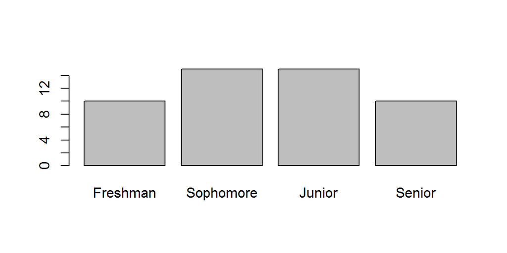

```r
plot(students)
```

If you need to recover the numeric values stored by R, use `as.numeric`. Note: If the labels of the factors are numbers, this still **wil not** return the labels. Use the methods listed above.

```r
as.numeric(students)
```

```
##  [1] 1 4 3 3 2 4 2 2 1 1 2 2 1 3 1 3 2 2 4 4 2 4 3 3 1 2 2 3 3 4 3 2 3 1 2
## [36] 2 1 4 1 4 3 3 1 3 2 3 2 4 4 3
```